# Problem Statement

## **Context:**

Fantasy sports are online gaming platforms where participants draft and manage virtual teams of real professional sports players. Based on the performance of the players in the real world, players are allotted points in the fantasy sports platform every match. The objective is to create the best possible team with a fixed budget to score maximum fantasy points, and users compete against each other over an entire sports league or season. Some of these fantasy sports require actual financial investments for participation, with the chances of winning monetary rewards as well as free matchday tickets on a periodic basis.

The fantasy sports market has seen tremendous growth over the past few years, with a valuation of \$18.6 billion in 2019. The football (soccer) segment led in terms of market share in 2019, with over 8 million participants worldwide, and is expected to retain its dominance over the next couple of years. Digitalization is one of the primary factors driving the growth of the fantasy sports market as it allows participants the opportunity to compete on a global level and test their skills. With an increase in smartphone usage and availability of fantasy sports apps, this market is expected to witness a globe surge and reach a \\$48.6 billion valuation by 2027.

## **Objective:**

OnSports is a fantasy sports platform that has fantasy leagues for many different sports and has witnessed an increasing number of participants globally over the past 5 years. For each player, a price is set at the start, and the price keeps changing over time based on the performance of the players in the real world. With the new English Premier League season about to start, they have collected data from the past season and want to analyze it to determine the price of each player for the start of the new season. OnSports have hired you as a data scientist and asked you to conduct a cluster analysis to identify players of different potentials of each player based on previous season performance. This will help them understand the patterns in player performances and fantasy returns and decide the exact price to be set for each player for the upcoming football season.

## **Data Description:**

- Player_Name: Name of the player.
- Club: Club in which the player plays.
- Position: Position in which the player plays.
- Goals_Scored: Number of goals scored by the player in the previous season.
- Assists: Number of passes made by the player leading to goals in the previous season.
- Total_Points: Total number of fantasy points scored by the player in the previous season.
- Minutes: Number of minutes played by the player in the previous season.
- Goals_Conceded: Number of goals conceded by the player in the previous season.
- Creativity: A score, computed using a range of stats, that assesses player performance in terms of producing goalscoring opportunities for other players.
- Influence: A score, computed using a range of stats, that evaluates a player's impact on a match, taking into account actions that could directly or indirectly affect the match outcome.
- Threat: A score, computed using a range of stats, that gauges players who are most likely to score goals.
- Bonus: Total bonus points received. The three best performing players in each match receive additional bonus points based on a score computed using a range of stats. 3 points are awarded to the highest scoring player, 2 to the second best, and 1 to the third.
- Clean_Sheets: Number of matches without conceding a goal in the previous season.

# Import

```python
import pandas as pd
import numpy as np
import matplotlib.pyplot as plt
import seaborn as sns

#to scale the data using z-score
from sklearn.preprocessing import StandardScaler

#Importing PCA and TSNE
from sklearn.decomposition import PCA

#importing clustering algorithms
from sklearn.cluster import KMeans
from sklearn.mixture import GaussianMixture

#Silhouette score
from sklearn.metrics import silhouette_score

import warnings
warnings.filterwarnings("ignore")
```

```python
from google.colab import drive
drive.mount('/content/drive')
```

# Load CSV File

```python
#Storing the data in df, change the path accordingly
df = pd.read_csv('/content/drive/MyDrive/GreatLearning/Optional Clustering Project/fpl_data.csv')

#Edits the number of columns and rows that will be shown without hiding. By default it shows top 5
pd.set_option('display.max_columns',100)
pd.set_option('display.max_rows',20)

df.head()
```

|  | Player_Name | Club | Position | Goals_Scored | Assists | Total_Points | Minutes | Goals_Conceded | Creativity | Influence | Threat | Bonus | Clean_Sheets |
| --- | --- | --- | --- | --- | --- | --- | --- | --- | --- | --- | --- | --- | --- |
| 0 | Alex Runnarsson | Arsenal | Goalkeeper | 0 | 0 | 1 | 15 | 0 | 0.0 | 16.6 | 0 | 0 | 0 |
| 1 | Alexandre Lacazette | Arsenal | Forward | 13 | 3 | 129 | 1916 | 21 | 307.4 | 602.4 | 797 | 21 | 7 |
| 2 | Bernd Leno | Arsenal | Goalkeeper | 0 | 0 | 131 | 3131 | 37 | 0.0 | 702.2 | 2 | 11 | 11 |
| 3 | Bukayo Saka | Arsenal | Midfielder | 5 | 5 | 114 | 2554 | 31 | 650.6 | 493.0 | 984 | 8 | 8 |
| 4 | Calum Chambers | Arsenal | Defender | 0 | 3 | 36 | 751 | 10 | 169.4 | 171.8 | 77 | 3 | 2 |

# Understanding Data

```python
df.shape
```

```
(476, 13)
```

```python
df.info()
```

```
<class 'pandas.core.frame.DataFrame'>
RangeIndex: 476 entries, 0 to 475
Data columns (total 13 columns):
 #   Column          Non-Null Count  Dtype
---  ------          --------------  -----
 0   Player_Name     476 non-null    object
 1   Club            476 non-null    object
 2   Position        476 non-null    object
 3   Goals_Scored    476 non-null    int64
 4   Assists         476 non-null    int64
 5   Total_Points    476 non-null    int64
 6   Minutes         476 non-null    int64
 7   Goals_Conceded  476 non-null    int64
 8   Creativity      476 non-null    float64
 9   Influence       476 non-null    float64
 10  Threat          476 non-null    int64
 11  Bonus           476 non-null    int64
 12  Clean_Sheets    476 non-null    int64
dtypes: float64(2), int64(8), object(3)
memory usage: 48.5+ KB
```

```python
df.describe(include='all') #This include will add in the categorical features
```

|  | Player_Name | Club | Position | Goals_Scored | Assists | Total_Points | Minutes | Goals_Conceded | Creativity | Influence | Threat | Bonus | Clean_Sheets |
| --- | --- | --- | --- | --- | --- | --- | --- | --- | --- | --- | --- | --- | --- |
| count | 476 | 476 | 476 | 476.000000 | 476.000000 | 476.000000 | 476.000000 | 476.000000 | 476.000000 | 476.000000 | 476.000000 | 476.000000 | 476.000000 |
| unique | 476 | 17 | 4 | NaN | NaN | NaN | NaN | NaN | NaN | NaN | NaN | NaN | NaN |
| top | Alex Runnarsson | Arsenal | Midfielder | NaN | NaN | NaN | NaN | NaN | NaN | NaN | NaN | NaN | NaN |
| freq | 1 | 30 | 195 | NaN | NaN | NaN | NaN | NaN | NaN | NaN | NaN | NaN | NaN |
| mean | NaN | NaN | NaN | 1.907563 | 1.752101 | 58.516807 | 1336.909664 | 19.157563 | 195.976050 | 294.617647 | 224.962185 | 4.718487 | 4.745798 |
| std | NaN | NaN | NaN | 3.455562 | 2.708563 | 51.293559 | 1073.773995 | 15.946171 | 251.478541 | 267.779681 | 318.240377 | 6.252625 | 4.394312 |
| min | NaN | NaN | NaN | 0.000000 | 0.000000 | 0.000000 | 0.000000 | 0.000000 | 0.000000 | 0.000000 | 0.000000 | 0.000000 | 0.000000 |
| 25% | NaN | NaN | NaN | 0.000000 | 0.000000 | 10.000000 | 268.750000 | 4.000000 | 8.300000 | 46.500000 | 5.750000 | 0.000000 | 0.000000 |
| 50% | NaN | NaN | NaN | 0.500000 | 0.000000 | 48.000000 | 1269.500000 | 18.000000 | 96.950000 | 233.100000 | 104.500000 | 2.000000 | 4.000000 |
| 75% | NaN | NaN | NaN | 2.000000 | 2.000000 | 94.250000 | 2256.250000 | 31.000000 | 296.950000 | 499.500000 | 298.250000 | 7.000000 | 8.000000 |
| max | NaN | NaN | NaN | 23.000000 | 14.000000 | 244.000000 | 3420.000000 | 68.000000 | 1414.900000 | 1318.200000 | 1980.000000 | 40.000000 | 19.000000 |

- Above codes tell us that there are 3 categorial variables, and the rest are numerical variables.
- The distribution of the numerical can also be seen here
- There is also no null values, but should double check again with the below codes

## Null value Check

```python
df.isnull().sum()
```

```
Player_Name       0
Club              0
Position          0
Goals_Scored      0
Assists           0
Total_Points      0
Minutes           0
Goals_Conceded    0
Creativity        0
Influence         0
Threat            0
Bonus             0
Clean_Sheets      0
dtype: int64
```

```python
for col in df.columns.to_list():
  nunique = df[col].value_counts()
  print(nunique)
  print('-'*50)
```

```
Alex Runnarsson     1
Axel Tuanzebe       1
Luke Shaw           1
Juan Mata           1
Harry Maguire       1
                   ..
Luka Milivojevic    1
Jordan Ayew         1
Joel Ward           1
Jeffrey Schlupp     1
Willy Boly          1
Name: Player_Name, Length: 476, dtype: int64
--------------------------------------------------
Arsenal                     30
Crystal Palace              30
Leeds United                29
West Ham United             29
Tottenham Hotspurs          29
Newcastle United            29
Leicester City              29
Manchester United           28
Chelsea                     28
Brighton and Hove Albion    28
Everton                     27
Liverpool                   27
Manchester City             27
Southampton                 27
Burnley                     27
Aston Villa                 26
Wolverhampton Wanderers     26
Name: Club, dtype: int64
--------------------------------------------------
Midfielder    195
Defender      172
Forward        64
Goalkeeper     45
Name: Position, dtype: int64
--------------------------------------------------
0     238
1      95
```

[output cut: 124 more lines]

```
10     27
2      27
9      25
6      23
7      23
8      20
12     18
14      8
13      7
16      2
15      1
19      1
17      1
Name: Clean_Sheets, dtype: int64
--------------------------------------------------
```

## Duplicated Value Check

```python
df.duplicated().sum()
#df[df.duplicated()] also does the trick
```

```
0
```

# Univariate Analysis

## Numerical variables

### Studying one variable first

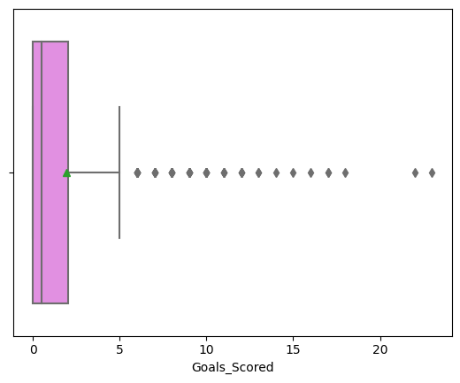

```python
sns.boxplot(data=df,x='Goals_Scored',showmeans = True, color = 'violet');
```

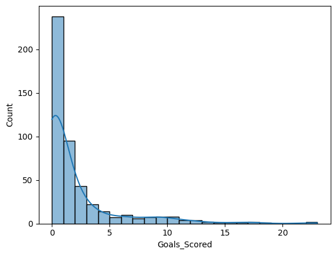

```python
sns.histplot(data=df,x = 'Goals_Scored',bins = 23, kde = True);
```

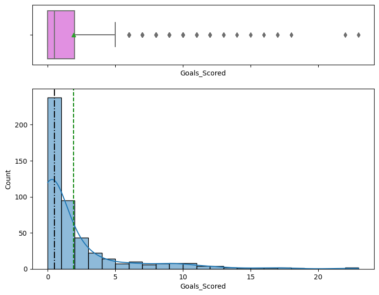

```python
#Combining the top 2 into a subplot
fig,ax = plt.subplots(2,1, #Creates a subplot with 2 rows and 1 column
                      sharex=True, #Makes the suboplot share their x axis
                      gridspec_kw = {'height_ratios':(1,3)}, #Sets the height ratio opf the 2 subplots into 1:3
                      figsize = (9,7))

#Creating the boxplot and set it at the first box
sns.boxplot(data=df,
            x='Goals_Scored',
            showmeans = True, #in boxplot, you can mark out the mean
            color = 'violet',
            ax = ax[0]) #Define this as the first of the subplot

#Creating the histplot and set it at the second box
sns.histplot(data=df,
             x = 'Goals_Scored',
             bins = 23,
             kde = True,
             ax = ax[1]) #The second boxplot

#Adding a line into the histogram to mark out the mean
ax[1].axvline(df['Goals_Scored'].mean(), #This command will create a vertical line, and the x value is at the mean
              linestyle = '--',
              color = 'green')

#Adding a line into the histogram to mark out the median
ax[1].axvline(df['Goals_Scored'].median(),#This command will create a vertical line, and the x value is at the median
              linestyle = '-.',
              color = 'black')
```

### Converting what we did above into a function

```python
def hist_box(df, feature, kde = False, bin = None): #Here we set the kde to be False by default and bin to be none by default
  #Create a subplot with 2 rows and 1 column
  fig,ax = plt.subplots(2,1,
                      sharex=True, #Makes the suboplot share their x axis
                      gridspec_kw = {'height_ratios':(1,3)}, #Sets the height ratio opf the 2 subplots into 1:3
                      figsize = (9,7))
  #Creating the boxplot and set it at the first box
  sns.boxplot(data=df,
              x=feature,
              showmeans = True, #in boxplot, you can mark out the mean
              color = 'violet',
              ax = ax[0]) #Define this as the first of the subplot

  #Creating the histplot and set it at the second box
  sns.histplot(data=df,
              x = feature,
              bins = bin,
              kde = kde,
              ax = ax[1]) #The second boxplot

  #Adding a line into the histogram to mark out the mean
  ax[1].axvline(df[feature].mean(), #This command will create a vertical line, and the x value is at the mean
                linestyle = '--',
                color = 'green')

  #Adding a line into the histogram to mark out the median
  ax[1].axvline(df[feature].median(),#This command will create a vertical line, and the x value is at the median
                linestyle = '-.',
                color = 'black')
```

### Studying all the different numerical variables

```python
df.head(1) #Calling this line helps us to call the function for all the features
```

|  | Player_Name | Club | Position | Goals_Scored | Assists | Total_Points | Minutes | Goals_Conceded | Creativity | Influence | Threat | Bonus | Clean_Sheets |
| --- | --- | --- | --- | --- | --- | --- | --- | --- | --- | --- | --- | --- | --- |
| 0 | Alex Runnarsson | Arsenal | Goalkeeper | 0 | 0 | 1 | 15 | 0 | 0.0 | 16.6 | 0 | 0 | 0 |

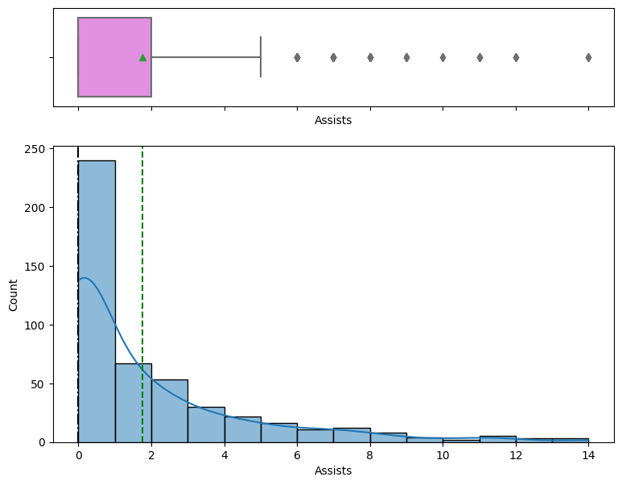

```python
hist_box(df,'Assists',True,14)
```

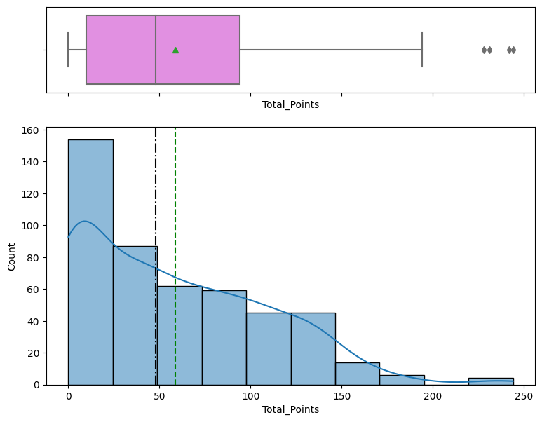

```python
hist_box(df,'Total_Points',True,10)
```

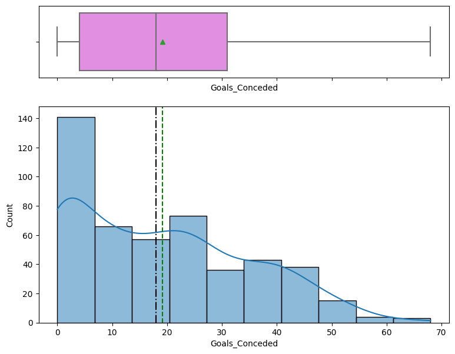

```python
hist_box(df,'Goals_Conceded',True,10)
```

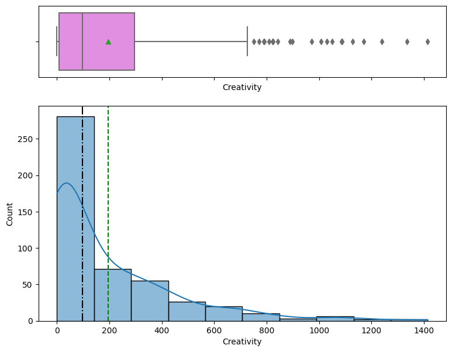

```python
hist_box(df,'Creativity',True,10)
```

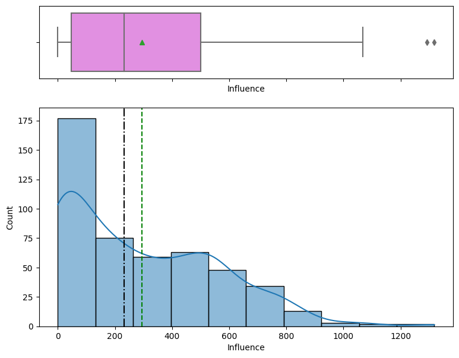

```python
hist_box(df,'Influence',True,10)
```

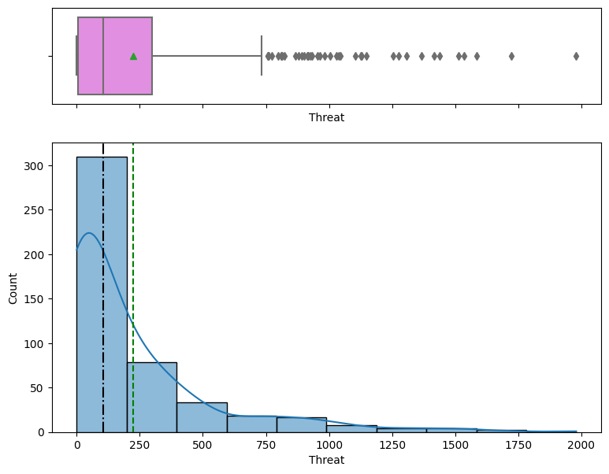

```python
hist_box(df,'Threat',True,10)
```

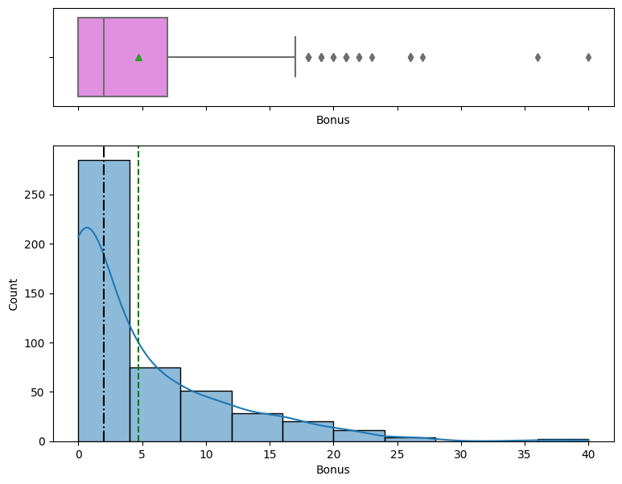

```python
hist_box(df,'Bonus',True,10)
```

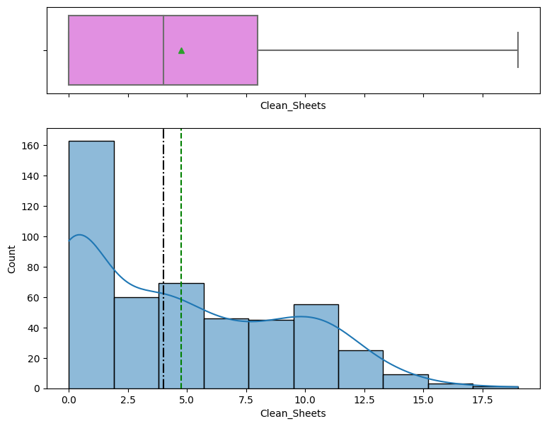

```python
hist_box(df,'Clean_Sheets',True,10)
```

## Categorical Variables

### Studying one Categorical variable first

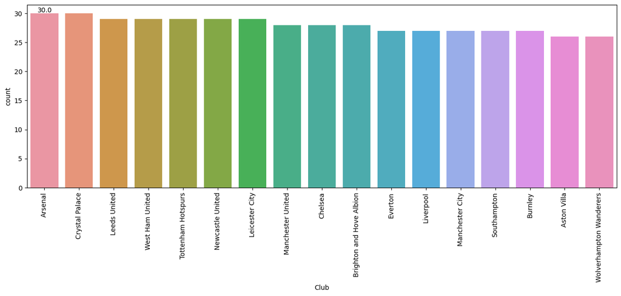

```python
#Set the figure size
plt.figure(figsize = (16,5))

#Create the countplot
ax = sns.countplot(data = df,
                  x = 'Club',
                  order = df.groupby(['Club'])['Player_Name'].count().sort_values(ascending = False).index) # This line counts the number of players in each club, sort it in ascending order, and get the index. This way we get the club names in descending order
#Rotate the x labels
plt.xticks(rotation = 90)

#Creating the labels
i = 0
x = ax.patches[i].get_x() + ax.patches[i].get_width()/2 - 0.2 #ax.patches[0] is referring the to the first patch of the graph. Patch is the shape, in this case the bars.
y = ax.patches[i].get_height() + 0.2
ax.annotate(ax.patches[i].get_height(),(x, y))

plt.show()
```

### Creating a function to automate above

```python
def labeled_barplot(data,feature,perc = False, n = None):
  total = len(data[feature])
  count = data[feature].nunique()

  #Changing size of the plot
  if n is None:
    plt.figure(figsize = (count + 1, 5)) #if n is not specified, then the size of the chart will be the according to number of features
  else:
    plt.figure(figsize = (n + 1, 5))

  #Rotate the x labels
  plt.xticks(rotation = 90, fontsize = 15)

  #Create the countplot and assigning it to object
  ax = sns.countplot(data = data,
                     x = feature,
                     palette = "Paired",
                     order = data[feature].value_counts().index[:n].sort_values(),)

  #Creating the labels
  for p in ax.patches:
    if perc == True:
      label = "{:.1f}%".format(100*p.get_height()/total) #Gets the percentage value of the height
    else:
      label = p.get_height() # Just get the height without percentage

    #Getting coordinates for the annotation
    x = p.get_x() + p.get_width()/2
    y = p.get_height()

    #Coding the annotations
    ax.annotate(label,(x,y),
                ha = "center",
                va = "center",
                size = 12,
                xytext = (0,5),
                textcoords = "offset points")

  plt.show()
```

### Study every other variable using the function

```python
df.head(1)
```

|  | Player_Name | Club | Position | Goals_Scored | Assists | Total_Points | Minutes | Goals_Conceded | Creativity | Influence | Threat | Bonus | Clean_Sheets |
| --- | --- | --- | --- | --- | --- | --- | --- | --- | --- | --- | --- | --- | --- |
| 0 | Alex Runnarsson | Arsenal | Goalkeeper | 0 | 0 | 1 | 15 | 0 | 0.0 | 16.6 | 0 | 0 | 0 |

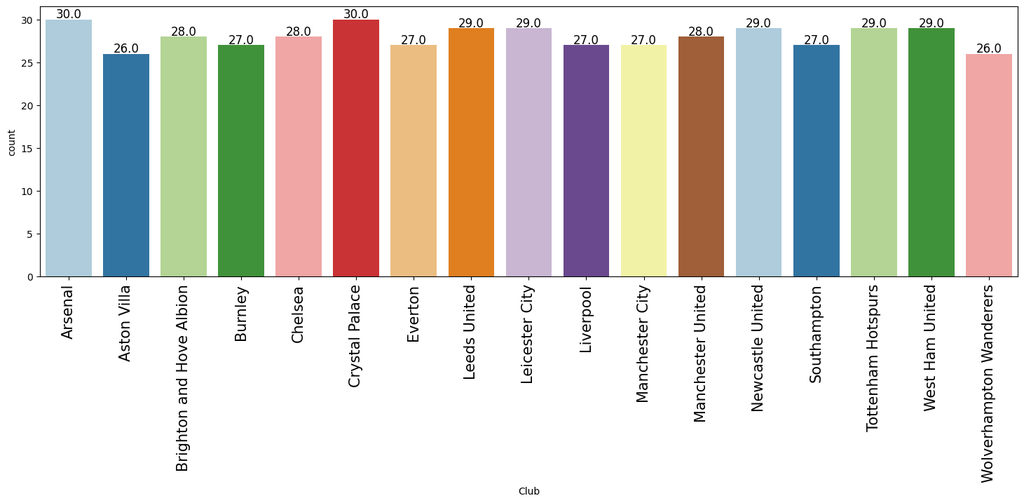

```python
labeled_barplot(df,'Club')
```

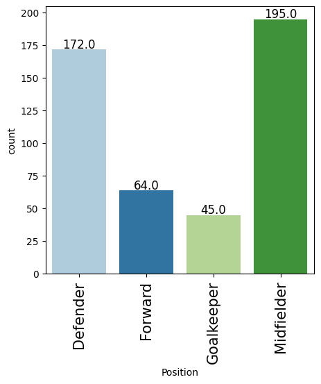

```python
labeled_barplot(df,'Position') #If i define n = 2, only the highest 2 bars will be plotted
```

# Bivariate Analysis

## Getting an overview

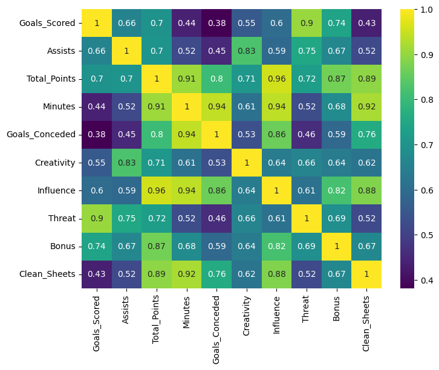

```python
plt.figure(figsize = (8,6))
sns.heatmap(df.corr(), annot = True, cmap = 'viridis')
```

Here, many of them have a strong positive correlations

## Things to investigate:

1. Which club has the most Total Points
2. Which position has the most Total Points
3. Which position plays the most Minutes
4. Which club earned the most Bonus points

## Which Club as the most Total Points

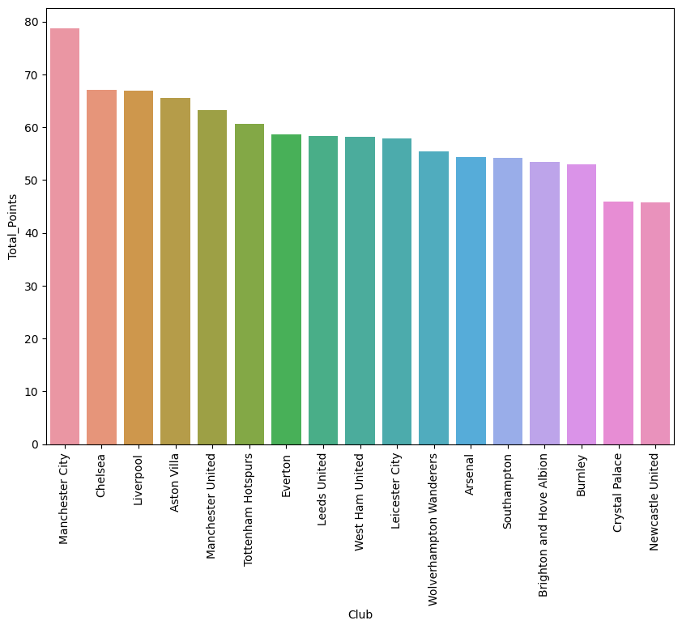

```python
plt.figure(figsize = (10,7));
sns.barplot(data = df,
            x='Club',
            y = 'Total_Points',
            ci = None,
            order = df.groupby(['Club'])['Total_Points'].mean().sort_values(ascending = False).index); #This allows us to sort the graph in descending order of the mean
plt.xticks(rotation = 90)
plt.show()
```

- Man City has the highest total points.
- Crystal Palace and Newcastle U has the lowest
- Maybe from here, you would recommend them to buy players from Manchester City instead of others if they have limited budget

## Position vs Total Points

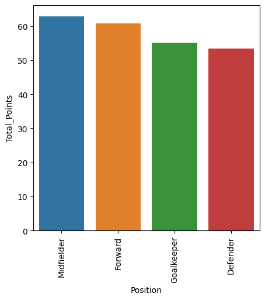

```python
# @title
plt.figure(figsize = (5,5));
sns.barplot(data=df,
            x='Position',
            y = 'Total_Points',
            ci = None,
            order = df.groupby(['Position'])['Total_Points'].mean().sort_values(ascending = False).index);
plt.xticks(rotation = 90)
plt.show()
```

- Seems like Midfielders earn the most total points, and Defender has the least. But not sure of the reasons yet, perhaps the positions play longer or more matches.

## Position vs Minutes

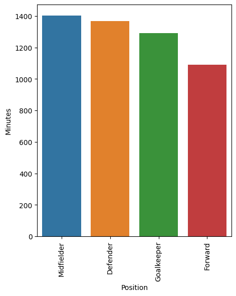

```python
# @title
plt.figure(figsize = (5,6));
sns.barplot(data=df,
            x='Position',
            y = 'Minutes',
            ci = None,
            order = df.groupby(['Position'])['Minutes'].mean().sort_values(ascending = False).index);
plt.xticks(rotation = 90)
plt.show()
```

- We can see that Midfielders play the most, maybe thats why they got the most total points.
- But one interesting thing taht can be observed here is that the Forwards play much lesesr than the rest. But somehow they still earn a lot of points.
- Maybe their position is more tiring/ injuries than the others?

## Club vs Bonus

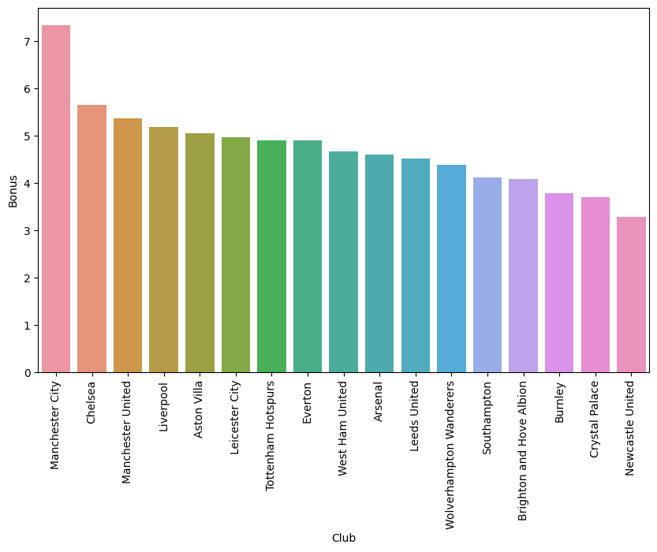

```python
#Bonus can be used to gauge the performance of the players too
plt.figure(figsize = (10,6));
sns.barplot(data=df,
            x='Club',
            y = 'Bonus',
            ci = None,
            order = df.groupby(['Club'])['Bonus'].mean().sort_values(ascending = False).index);
plt.xticks(rotation = 90)
plt.show()
```

## Finding the top 3 Players from each position who earned the most points

Finding one first

```python
df['Position'] #This will give me all the info from the column: position
df[df['Position'] == 'Forward'] #This will give me all the rows with the forward position
df[df['Position'] == 'Forward']['Total_Points'] #This will give me all the Total_points from each player in the forward position
df[df['Position'] == 'Forward']['Total_Points'].max() #This is the max value from the forward position
df[df['Position'] == 'Forward']['Total_Points'].sort_values(ascending = False) #This will give me the values from the forwards position but in descending order
df[df['Position'] == 'Forward']['Total_Points'].sort_values(ascending = False).index[0:10] #This will give me the index of the top 10 values from the forward positions in descnding order, so the top 10
df.loc[df[df['Position'] == 'Forward']['Total_Points'].sort_values(ascending = False).index[0:10]] #Now this will give me the rows of the top 10 values from the previous list
df1 = df.loc[df[df['Position'] == 'Forward']['Total_Points'].sort_values(ascending = False).index[0:10],['Player_Name','Club','Position','Total_Points']] #This will return the requested information from above dataframe and assign it to df1
df1
```

|  | Player_Name | Club | Position | Total_Points |
| --- | --- | --- | --- | --- |
| 403 | Harry Kane | Tottenham Hotspurs | Forward | 242 |
| 219 | Patrick Bamford | Leeds United | Forward | 194 |
| 238 | Jamie Vardy | Leicester City | Forward | 187 |
| 51 | Ollie Watkins | Aston Villa | Forward | 168 |
| 177 | Dominic Calvert-Lewin | Everton | Forward | 165 |
| 275 | Roberto Firmino | Liverpool | Forward | 141 |
| 90 | Chris Wood | Burnley | Forward | 138 |
| 367 | Che Adams | Southampton | Forward | 137 |
| 338 | Callum Wilson | Newcastle United | Forward | 134 |
| 369 | Danny Ings | Southampton | Forward | 131 |

Doing the same for the others using a for loop

```python
#Create a empty dataframe for the loop to work with
df1 = pd.DataFrame({})

#The loop for every unique position
for pos in df['Position'].unique().tolist(): #This gives us a list of the unique positions
  df2 = df.loc[df[df['Position'] == pos]['Total_Points'].sort_values(ascending = False).index[0:3],['Player_Name','Club','Position','Total_Points']] #Run the above code for each position
  df1 = pd.concat([df1,df2]) #Store them in df1, which will then be used in the next loop

#Didn't even need to drop duplicates because there shouldn't be any
df1
```

|  | Player_Name | Club | Position | Total_Points |
| --- | --- | --- | --- | --- |
| 36 | Emiliano Martinez | Aston Villa | Goalkeeper | 186 |
| 284 | Ederson Moares | Manchester City | Goalkeeper | 160 |
| 203 | Illan Meslier | Leeds United | Goalkeeper | 154 |
| 403 | Harry Kane | Tottenham Hotspurs | Forward | 242 |
| 219 | Patrick Bamford | Leeds United | Forward | 194 |
| 238 | Jamie Vardy | Leicester City | Forward | 187 |
| 315 | Bruno Fernandes | Manchester United | Midfielder | 244 |
| 269 | Mohamed Salah | Liverpool | Midfielder | 231 |
| 405 | Heung-Min Son | Tottenham Hotspurs | Midfielder | 228 |
| 223 | Stuart Dallas | Leeds United | Defender | 171 |
| 257 | Andrew Robertson | Liverpool | Defender | 161 |
| 278 | Trent Alexander-Arnold | Liverpool | Defender | 160 |

# Outlier Analysis

## Analyzing one of them: Goals Scored

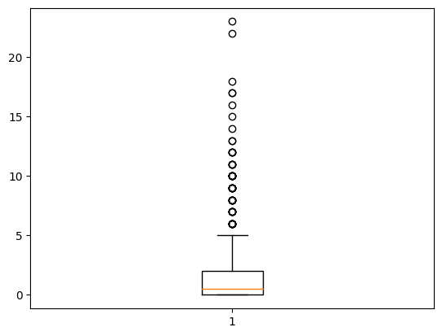

```python
plt.boxplot(df['Goals_Scored'], whis = 1.5);
```

They got so many outliers

## Now lets do the same for all the other numerical columns

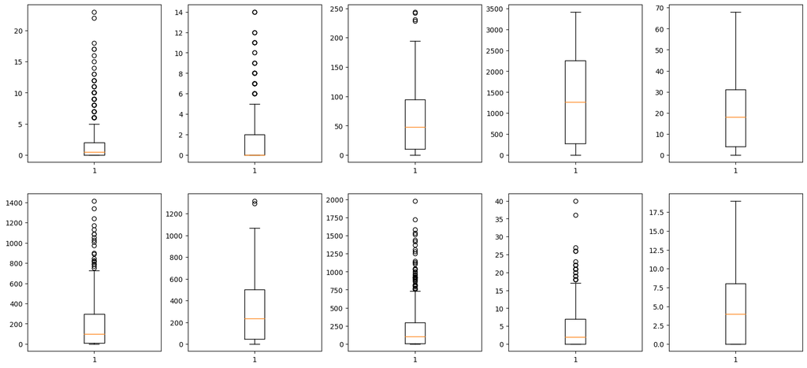

```python
num_col = df.select_dtypes(np.number).columns.values

plt.figure(figsize = [20,9])

for i,j in enumerate(num_col):
  plt.subplot(2, 5, i+1)
  plt.boxplot(df[j])
```

# Preprocessing Data

## Standardization

```python
scaler = StandardScaler()

#This scaler can only be used on numerical variables, which is what we have defined earlier
scaler.fit(df[num_col]) # This basically puts the scaler on top of the data, so 'fitting the data into the scaler'
scaled_df = scaler.transform(df[num_col]) # Now we transform the data that was fitted into the scaler

#This is how we usuall do it, and its the same as above
# scaled_df=pd.DataFrame(scaler.fit_transform(df[num_col]), columns=num_col)
# scaled_df

#Now we convert the scaled values back into its dataframe format
scaled_df = pd.DataFrame(scaled_df, columns = num_col)
scaled_df
```

|  | Goals_Scored | Assists | Total_Points | Minutes | Goals_Conceded | Creativity | Influence | Threat | Bonus | Clean_Sheets |
| --- | --- | --- | --- | --- | --- | --- | --- | --- | --- | --- |
| 0 | -0.552608 | -0.647555 | -1.122506 | -1.232383 | -1.202653 | -0.780115 | -1.039325 | -0.707638 | -0.755435 | -1.081123 |
| 1 | 3.213401 | 0.461208 | 1.375560 | 0.539871 | 0.115663 | 0.443542 | 1.150596 | 1.799393 | 2.606688 | 0.513521 |
| 2 | -0.552608 | -0.647555 | 1.414592 | 1.672585 | 1.120094 | -0.780115 | 1.523682 | -0.701346 | 1.005677 | 1.424747 |
| 3 | 0.895857 | 1.200384 | 1.082818 | 1.134662 | 0.743432 | 1.809706 | 0.741621 | 2.387618 | 0.525374 | 0.741328 |
| 4 | -0.552608 | 0.461208 | -0.439441 | -0.546229 | -0.574884 | -0.105790 | -0.459134 | -0.465428 | -0.275132 | -0.625510 |
| ... | ... | ... | ... | ... | ... | ... | ... | ... | ... | ... |
| 471 | -0.552608 | -0.647555 | -1.122506 | -1.086016 | -0.763215 | -0.679404 | -0.984745 | -0.707638 | -0.755435 | -1.081123 |
| 472 | -0.552608 | -0.647555 | 1.434108 | 1.858107 | 1.998971 | -0.780115 | 1.753217 | -0.707638 | 1.165778 | 1.196940 |
| 473 | -0.552608 | -0.277967 | -0.634602 | -0.771839 | -0.700438 | -0.067576 | -0.802314 | -0.481156 | -0.755435 | -1.081123 |
| 474 | -0.262915 | -0.277967 | -0.361377 | -0.215271 | -0.386553 | -0.119723 | -0.766426 | 0.097632 | -0.275132 | 0.057909 |
| 475 | -0.262915 | -0.277967 | 0.185075 | 0.505377 | 0.617878 | -0.596606 | 0.446292 | -0.135141 | -0.115031 | 0.285715 |

476 rows × 10 columns

## How Scaling work

```python
(df['Goals_Scored'] - df['Goals_Scored'].mean())/df['Goals_Scored'].std()
#It is actually the error divide by the standard deviation.
```

```
0     -0.552027
1      3.210024
2     -0.552027
3      0.894916
4     -0.552027
         ...
471   -0.552027
472   -0.552027
473   -0.552027
474   -0.262638
475   -0.262638
Name: Goals_Scored, Length: 476, dtype: float64
```

## PCA

```python
pca = PCA(n_components = scaled_df.shape[1],random_state = 1) # Defining the number of principle components, and fix the randomness
pca.fit(scaled_df) # fitting the PCA tool on top of the array
pca_df = pca.transform(scaled_df) # transforming scaled_df into a pca array, and storing it in the pca_df

# Once again, it is the same as the below, but split down to further understand what they are doing
# pca1 = PCA(n_components=n, random_state=1)
# data_pca = pd.DataFrame(pca1.fit_transform(data_scaled))

pca_df = pd.DataFrame(pca_df) #Converting the array into DataFrame
pca_df
```

|  | 0 | 1 | 2 | 3 | 4 | 5 | 6 | 7 | 8 | 9 |
| --- | --- | --- | --- | --- | --- | --- | --- | --- | --- | --- |
| 0 | -2.916600 | 0.569939 | -0.041871 | 0.190663 | 0.003485 | 0.008158 | -0.042314 | 0.064757 | 0.057486 | 0.006269 |
| 1 | 3.815468 | 1.999554 | -2.216345 | 0.757341 | -0.119000 | -0.541975 | -0.233941 | -0.293053 | 0.075356 | -0.238019 |
| 2 | 1.943396 | -2.757446 | -0.958238 | 0.816920 | 0.041188 | 0.376978 | 0.005235 | 0.138392 | -0.306183 | -0.136656 |
| 3 | 3.502427 | 1.043441 | 0.581995 | -0.969567 | 0.415848 | -0.358456 | 0.661746 | 0.376272 | -0.260200 | -0.155934 |
| 4 | -1.153639 | 0.422189 | 0.642307 | 0.269271 | -0.271583 | 0.405367 | -0.033575 | 0.098886 | -0.035234 | -0.034877 |
| ... | ... | ... | ... | ... | ... | ... | ... | ... | ... | ... |
| 471 | -2.686929 | 0.350179 | 0.012579 | -0.028976 | -0.226985 | -0.079117 | -0.016498 | -0.025886 | 0.114191 | 0.056974 |
| 472 | 2.333559 | -3.137873 | -1.051056 | 0.486420 | -0.652311 | 0.294376 | 0.067490 | 0.094238 | -0.214251 | 0.007010 |
| 473 | -1.966630 | 0.469243 | 0.474989 | -0.098289 | -0.221093 | -0.163924 | -0.057647 | 0.129321 | -0.267969 | -0.017272 |
| 474 | -0.818000 | 0.180940 | 0.103096 | -0.112637 | 0.423414 | -0.064093 | 0.399416 | -0.300399 | -0.000771 | -0.068806 |
| 475 | 0.261544 | -1.032869 | -0.417139 | -0.260951 | -0.095053 | 0.293633 | 0.009004 | 0.112068 | 0.029016 | 0.002177 |

476 rows × 10 columns

In the DataFrame, each column is one principle component, and the variance of the PCs is decreasing down the column. This can be seen in the following codes

```python
explained_variance = pca_df.var()/sum(pca_df.var())
print(explained_variance)
print('-'*50)

pca.explained_variance_ratio_ # You will see that this and the above code is producing the same thing
```

```
0    0.721489
1    0.136593
2    0.058800
3    0.031384
4    0.022745
5    0.015227
6    0.007008
7    0.003937
8    0.001945
9    0.000870
dtype: float64
--------------------------------------------------
```

```
array([0.72148934, 0.13659346, 0.05880028, 0.03138379, 0.02274545,
       0.01522727, 0.00700781, 0.00393725, 0.00194529, 0.00087005])
```

```python
sum(pca.explained_variance_ratio_[:5]) #sum of the first 5 values of this array
```

```
0.9710123249796081
```

97% of the variance can be explained by the first 5 PCs, so the rest can actually be thrown away and not cause much issues

# K-Means Clustering

## Elbow Method

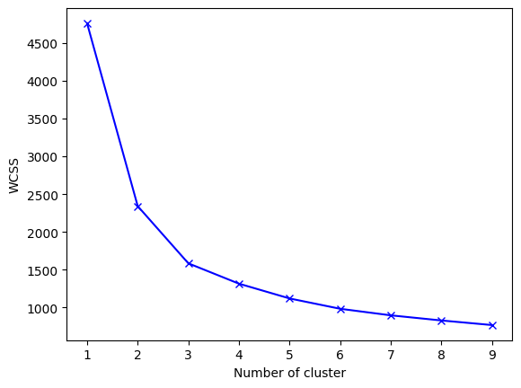

```python
#Create an empty dictionary to store the WCSS for each value of k
WCSS = {}

#Find the WCSS value for each value of k using the function
for k in range(1, 10):
    kmeans = KMeans(n_clusters=k,random_state=1).fit(pca_df) #Creating the Kmeans clustering from data_scaled using K clusters with a fixed randomness
    WCSS[k] = kmeans.inertia_ #Intertia is the WCSS

#Plot the Elbow
plt.figure()
plt.plot(list(WCSS.keys()), list(WCSS.values()), 'bx-')
plt.xlabel("Number of cluster")
plt.ylabel("WCSS")
plt.show()
```

## Silhouette Score

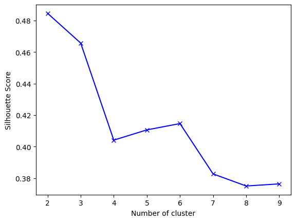

```python
sc = {}

for k in range(2, 10):
    kmeans = KMeans(n_clusters=k, random_state=1).fit(pca_df)
    labels = kmeans.predict(pca_df)
    sc[k] = silhouette_score(pca_df,labels)

#Plot the Elbow
plt.figure()
plt.plot(list(sc.keys()), list(sc.values()), 'bx-')
plt.xlabel("Number of cluster")
plt.ylabel("Silhouette Score")
plt.show()
```

## K-Means Clustering

Perform kmeans clustering

```python
#Create the 4 cluster K mean model
model = KMeans(n_clusters = 4, random_state = 0)

#Fit our data into the model that was created
model.fit(pca_df)
```

```
KMeans(n_clusters=4, random_state=0)
```

```python
#To differentiate this K means trained model from other models
model_kmeans = model

#Creating a copy of the scaled DataFrame to add the labels from the clustering
df_kmeans = scaled_df.copy()

#Create a new column called labels, and assign the values from the kmean models to the respective rows
df_kmeans['labels'] = model_kmeans.labels_
df_kmeans
```

|  | Goals_Scored | Assists | Total_Points | Minutes | Goals_Conceded | Creativity | Influence | Threat | Bonus | Clean_Sheets | labels |
| --- | --- | --- | --- | --- | --- | --- | --- | --- | --- | --- | --- |
| 0 | -0.552608 | -0.647555 | -1.122506 | -1.232383 | -1.202653 | -0.780115 | -1.039325 | -0.707638 | -0.755435 | -1.081123 | 2 |
| 1 | 3.213401 | 0.461208 | 1.375560 | 0.539871 | 0.115663 | 0.443542 | 1.150596 | 1.799393 | 2.606688 | 0.513521 | 1 |
| 2 | -0.552608 | -0.647555 | 1.414592 | 1.672585 | 1.120094 | -0.780115 | 1.523682 | -0.701346 | 1.005677 | 1.424747 | 3 |
| 3 | 0.895857 | 1.200384 | 1.082818 | 1.134662 | 0.743432 | 1.809706 | 0.741621 | 2.387618 | 0.525374 | 0.741328 | 1 |
| 4 | -0.552608 | 0.461208 | -0.439441 | -0.546229 | -0.574884 | -0.105790 | -0.459134 | -0.465428 | -0.275132 | -0.625510 | 0 |
| ... | ... | ... | ... | ... | ... | ... | ... | ... | ... | ... | ... |
| 471 | -0.552608 | -0.647555 | -1.122506 | -1.086016 | -0.763215 | -0.679404 | -0.984745 | -0.707638 | -0.755435 | -1.081123 | 2 |
| 472 | -0.552608 | -0.647555 | 1.434108 | 1.858107 | 1.998971 | -0.780115 | 1.753217 | -0.707638 | 1.165778 | 1.196940 | 3 |
| 473 | -0.552608 | -0.277967 | -0.634602 | -0.771839 | -0.700438 | -0.067576 | -0.802314 | -0.481156 | -0.755435 | -1.081123 | 2 |
| 474 | -0.262915 | -0.277967 | -0.361377 | -0.215271 | -0.386553 | -0.119723 | -0.766426 | 0.097632 | -0.275132 | 0.057909 | 0 |
| 475 | -0.262915 | -0.277967 | 0.185075 | 0.505377 | 0.617878 | -0.596606 | 0.446292 | -0.135141 | -0.115031 | 0.285715 | 0 |

476 rows × 11 columns

## Cluster Profiling Method 1

```python
#Get the mean and median of all the columns according to the labels
mean = df_kmeans.groupby('labels').mean()
median = df_kmeans.groupby('labels').median()

#Combie these 2 data together
kmeans_profile = pd.concat([mean, median], axis=0)

#Label the indexes of the dataframe
kmeans_profile.index = ['group_0 Mean', 'group_1 Mean', 'group_2 Mean','group_3 Mean', 'group_0 Median', 'group_1 Median', 'group_2 Median','group_3 Median']
kmeans_profile.T
```

|  | group_0 Mean | group_1 Mean | group_2 Mean | group_3 Mean | group_0 Median | group_1 Median | group_2 Median | group_3 Median |
| --- | --- | --- | --- | --- | --- | --- | --- | --- |
| Goals_Scored | -0.116945 | 2.107739 | -0.509462 | -0.157572 | -0.262915 | 2.054629 | -0.552608 | -0.262915 |
| Assists | -0.054496 | 1.834844 | -0.572851 | 0.046822 | -0.277967 | 1.569972 | -0.647555 | -0.277967 |
| Total_Points | -0.048362 | 1.632197 | -0.950286 | 0.878391 | -0.107667 | 1.482898 | -1.063957 | 0.809592 |
| Minutes | 0.052046 | 1.044480 | -1.023786 | 1.243324 | 0.036443 | 1.135128 | -1.151741 | 1.175682 |
| Goals_Conceded | 0.088897 | 0.901421 | -0.955887 | 1.153068 | 0.052886 | 0.868986 | -1.077100 | 1.120094 |
| Creativity | -0.030321 | 1.700404 | -0.667973 | 0.277435 | -0.119723 | 1.468762 | -0.761804 | 0.260431 |
| Influence | -0.088969 | 1.381376 | -0.940016 | 1.063813 | -0.092777 | 1.126297 | -1.037830 | 0.951716 |
| Threat | -0.005368 | 2.062155 | -0.612500 | -0.079665 | -0.182325 | 1.948809 | -0.695055 | -0.113122 |
| Bonus | -0.218041 | 1.848876 | -0.689862 | 0.473624 | -0.275132 | 1.726132 | -0.755435 | 0.365273 |
| Clean_Sheets | -0.009197 | 1.026086 | -0.953891 | 1.201542 | -0.169898 | 1.196940 | -1.081123 | 1.196940 |

## Cluster Profiling Method 2

```python
#Creating a new dataframe based on the labels and the mean of all the features
cluster_kmeans = df_kmeans.groupby('labels').mean()

#Create a column that tabulates the total nomber of players in each label because that is our variabale of interest
cluster_kmeans['count']=df_kmeans.groupby('labels')['Goals_Scored'].count().values

#highlight the max value of each features
cluster_kmeans.style.highlight_max()
```

| labels | Goals_Scored | Assists | Total_Points | Minutes | Goals_Conceded | Creativity | Influence | Threat | Bonus | Clean_Sheets | count |
| --- | --- | --- | --- | --- | --- | --- | --- | --- | --- | --- | --- |
| 0 | -0.116945 | -0.054496 | -0.048362 | 0.052046 | 0.088897 | -0.030321 | -0.088969 | -0.005368 | -0.218041 | -0.009197 | 129 |
| 1 | 2.107739 | 1.834844 | 1.632197 | 1.044480 | 0.901421 | 1.700404 | 1.381376 | 2.062155 | 1.848876 | 1.026086 | 60 |
| 2 | -0.509462 | -0.572851 | -0.950286 | -1.023786 | -0.955887 | -0.667973 | -0.940016 | -0.612500 | -0.689862 | -0.953891 | 188 |
| 3 | -0.157572 | 0.046822 | 0.878391 | 1.243324 | 1.153068 | 0.277435 | 1.063813 | -0.079665 | 0.473624 | 1.201542 | 99 |

- Label 1 has the best players
- Label 3 has the most used players

```python
cluster_kmeans.style.highlight_min(color = 'limegreen')
```

| labels | Goals_Scored | Assists | Total_Points | Minutes | Goals_Conceded | Creativity | Influence | Threat | Bonus | Clean_Sheets | count |
| --- | --- | --- | --- | --- | --- | --- | --- | --- | --- | --- | --- |
| 0 | -0.116945 | -0.054496 | -0.048362 | 0.052046 | 0.088897 | -0.030321 | -0.088969 | -0.005368 | -0.218041 | -0.009197 | 129 |
| 1 | 2.107739 | 1.834844 | 1.632197 | 1.044480 | 0.901421 | 1.700404 | 1.381376 | 2.062155 | 1.848876 | 1.026086 | 60 |
| 2 | -0.509462 | -0.572851 | -0.950286 | -1.023786 | -0.955887 | -0.667973 | -0.940016 | -0.612500 | -0.689862 | -0.953891 | 188 |
| 3 | -0.157572 | 0.046822 | 0.878391 | 1.243324 | 1.153068 | 0.277435 | 1.063813 | -0.079665 | 0.473624 | 1.201542 | 99 |

- Label 2 has the least valuable players, and there are a lot of them

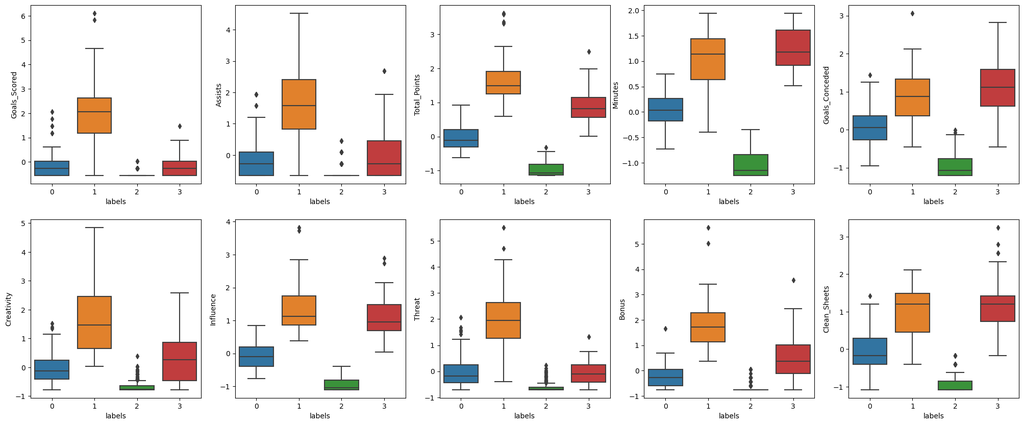

```python
fig,ax = plt.subplots(2,5,figsize = (25,10))

for i in range(2):
  for j in range(5):
    sns.boxplot(data = df_kmeans,x = 'labels', y = num_col[5*i+j],ax = ax[i][j])
```